# Course Project 1

## Loading and preprocessing the data.

### Load the data (i.e. read.csv())

```r
url <- "/Users/jonathan.mcnulty/activity.csv"

activity <- read.csv(url, header = T, sep = ",")
```

### Process/transform the data (if necessary) into a format suitable for your analysis.

```r
library(lubridate)
activity$date <- ymd(activity$date)
```

## What is mean total number of steps taken per day?

### Calculate the total number of steps taken per day.

```r
totalStepsPerDay <- tapply(activity$steps, activity$date, FUN = sum, na.rm = T)
```

### Make a histogram of the total number of steps taken each day.

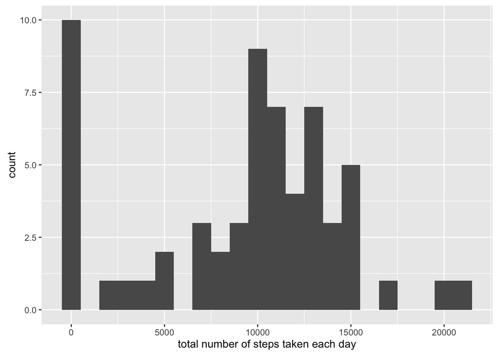

```r
library(ggplot2)
qplot(totalStepsPerDay, binwidth=1000, xlab="total number of steps taken each day")
```

### Calculate and report the mean and median of the total number of steps taken per day.

```r
mean(totalStepsPerDay, na.rm = T)
```

```
## [1] 9354.23
```

```r
median(totalStepsPerDay, na.rm = T)
```

```
## [1] 10395
```

## What is the average daily activity pattern?

### Make a time series plot (i.e. 𝚝𝚢𝚙𝚎 = “𝚕”) of the 5-minute interval (x-axis) and the average number of steps taken, averaged across all days (y-axis).

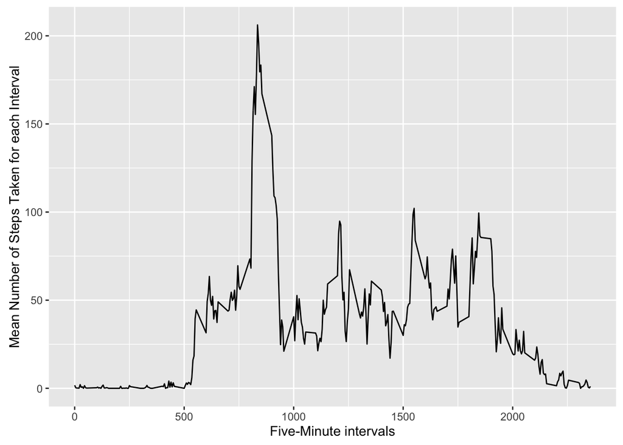

```r
library(ggplot2)
means <- aggregate(x=list(steps=activity$steps), by=list(interval=activity$interval),
                      FUN = mean, na.rm = T)
ggplot(data = means, aes(x = interval, y = steps)) +
        geom_line() +
        xlab("Five-Minute intervals") +
        ylab("Mean Number of Steps Taken for each Interval")
```

### Which 5-minute interval, on average, across all the days in the dataset, contains the maximum number of steps?

```r
means[which.max(means$steps), ]
```

```
##     interval    steps
## 104      835 206.1698
```

## Imputing missing values.

### Calculate and report the total number of missing values in the dataset (i.e. the total number of rows with 𝙽𝙰s)

```r
NAs <- is.na(activity$steps)
table(NAs) # How many missing
```

```
## NAs
## FALSE  TRUE
## 15264  2304
```

### Devise a strategy for filling in all of the missing values in the dataset. The strategy does not need to be sophisticated. For example, you could use the mean/median for that day, or the mean for that 5-minute interval, etc.

```r
activity[, 1] <- lapply(activity, function(x) {
  x[is.na(x)] <- mean(x, na.rm = T)
  x
})
```

### Create a new dataset that is equal to the original dataset but with the missing data filled in.

```r
fillActivity <- function(steps, interval) {
        imputedVal <- NA
        if (!is.na(steps))
                imputedVal <- c(steps)
        else
                imputedVal <- (means[means$interval == interval, "steps"])
        return(imputedVal)
}
filledActivity <- activity
filledActivity$steps <- mapply(fillActivity, filledActivity$steps, filledActivity$interval)
```

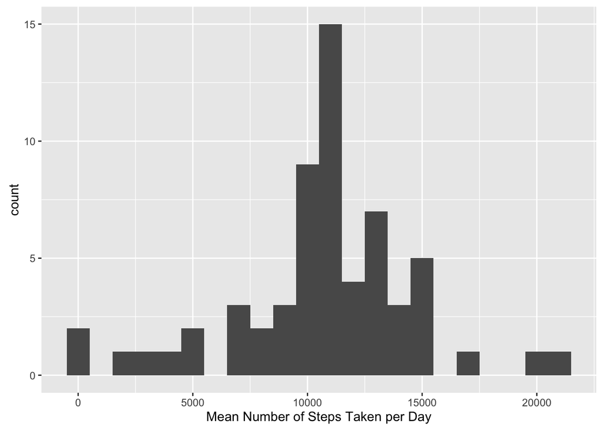

```r
totalStepsPerDay <- tapply(filledActivity$steps, filledActivity$date, FUN = sum)
qplot(totalStepsPerDay, binwidth = 1000, xlab="Mean Number of Steps Taken per Day")
```

### … and calculate and report the mean and median total number of steps taken per day.

```r
mean(totalStepsPerDay)
```

```
## [1] 10766.19
```

```r
median(totalStepsPerDay)
```

```
## [1] 10766.19
```

## Are there differences in activity patterns between weekdays and weekends?

### Create a new factor variable in the dataset with two levels – “weekday” and “weekend” indicating whether a given date is a weekday or weekend day.

```r
filledActivity$dayCategory <- ifelse(as.POSIXlt(filledActivity$date)$wday %in% c(0,6), 'weekend', 'weekday')
```

**People during weekdays are generally more active during earlier in the time series, with a slight ‘M’-shape to the curve measuring number of steps taken; this shape may reflect commuting patterns (to work in the morning and from work in the evening).**

**The concave shape of the weekend time series is indicative of a typical non-workday; slow start in the morning, busy middle of the day, and restful end to the day.**

### Make a panel plot containing a time series plot.

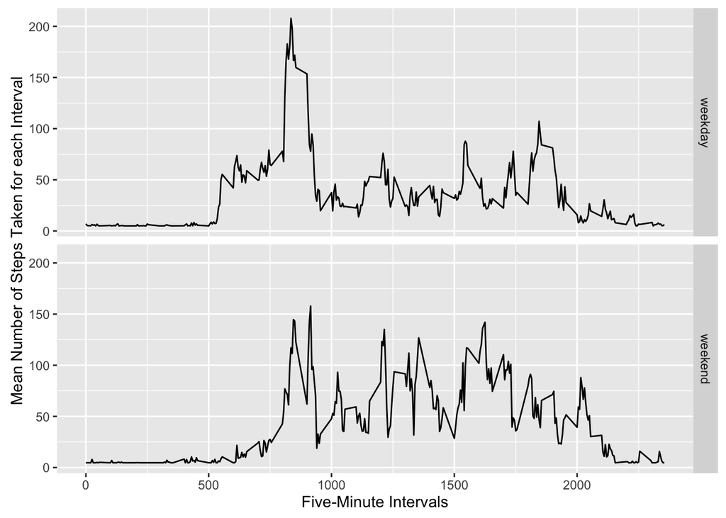

```r
library(stats)
meanFilledActivity <- aggregate(steps ~ interval + dayCategory, data = filledActivity, mean)
ggplot(meanFilledActivity, aes(interval, steps)) +
        geom_line() +
        facet_grid(dayCategory ~ .) +
        xlab("Five-Minute Intervals") +
        ylab("Mean Number of Steps Taken for each Interval")
```